# Project 3

# Introduction

The objective of this project was to compile data indicative of current data science skills in demand. We did this by creating multiple tables containing strings from blog posts along with populating data from actual job postings.

In doing this, we sought to answer three questions:

1. How do the skills vary between the different job posting sites?
2. How does the skills looked for in job postings compare to the skills recommended in articles and blogs?
3. Is there any difference in the 3 categories: Languages, Tech Data and Soft Skills

# Step 1: Listing skills based on job postings

Our first main step was creating a table that populated data based on 1) skills in demand from data blogs and 2) job postings with the skills listed.

## Performing Web Scraping to fetch the skills using the node selector

We used the `rvest` package to use a node selector and subset the skills of interest:

```r
# Start by reading a HTML page with read_html():
skills_page <- read_html("https://brainstation.io/career-guides/data-science-resume-examples#what-skills-should-you-put-on-a-data-science-resume")
skills_set1<- skills_page %>% html_nodes("ul:nth-child(4)") %>% html_elements("li")  %>% html_text2()
skills_set2<- skills_page %>% html_nodes("ul:nth-child(6)") %>% html_elements("li")  %>% html_text2()
```

From here, we can preview the vector:

```r
writeLines(skills_set1)
```

```
## Data Courses
## Data Analytics
## Data Science
## Python
## Cybersecurity
## Data analysis
## Data wrangling
## Data modeling
## Statistics
## Data visualization
## Programming
## Quantitative analysis
## Machine learning
## Machine learning models
## Data mining
## Debugging
## Hypothesis testing
## A/B tests
## Regression
## Research the company, the role, and relevant data skills
## Reference resume templates and samples to build a resume outline
## Add relevant education experience, work experience and data projects to the correct section of your resume
## Highlight experience with machine learning and data tools
## Craft concise bullet points using the action verb + task + result format for each experience, emphasizing data-driven successes
## Have a trusted peer proofread your Data Scientist resume for grammar and spelling to make sure your experience is professionally presented
## Work on projects in a collaborative setting
## Take advantage of our flexible plans and scholarships
## Get access to VIP events and workshops
```

The next step we took was trimming extra spaces from the words in `skill_set1` and `skill_set2`.

```r
vector1 = c()
for (i in 6:19) {
  vector1[i-5] <- as.character(trimws(skills_set1[i], which = c("both")))
}

vector2 = c()
for (i in 3:34) {
  vector2[i-2] <- as.character(trimws(skills_set2[i], which = c("both")))
}
```

Here are the cleaned vectors:

```r
vector1 %>% writeLines()
```

```
## Data analysis
## Data wrangling
## Data modeling
## Statistics
## Data visualization
## Programming
## Quantitative analysis
## Machine learning
## Machine learning models
## Data mining
## Debugging
## Hypothesis testing
## A/B tests
## Regression
```

```r
vector2 %>% writeLines()
```

```
## R
## Python
## C
## C++
## C#
## HTML
## Java
## JavaScript
## PHP
## SAS
## SQL
## Scala
## MATLAB
## SQL Server
## NoSQL
## Hadoop
## OpenRefine
## TensorFlow
## Cloudera
## Tableau
## Microsoft Excel
## Octave
## Spark
## PowerBI
## Plotly
## Bokeh
## Matplotlib
## Seaborn
## Keras
## Pytorch
## AWS
## Hive
```

*Soft Skills:* We can start by reading a HTML page with `read_html()`:

```r
softskills_page <- read_html("https://zety.com/blog/data-scientist-resume-example")
```

From here, we can scrap these using node selector

```r
skills_set3<- softskills_page %>% html_nodes("td:nth-child(1) > p > a") %>% html_text2()

skills_set3[3:9]
```

```
## [1] "Soft Skills"          "Communication"        "Collaboration"
## [4] "Creative Thinking"    "Critical Thinking"    "Problem Solving"
## [7] "Interpersonal Skills"
```

As before, we now have a vector of soft skills:

```r
vector3 = c()

for (i in 3:9) {

  vector3[i-2] <- as.character(trimws(skills_set3[i], which = c("both")))

}

vector3
```

```
## [1] "Soft Skills"          "Communication"        "Collaboration"
## [4] "Creative Thinking"    "Critical Thinking"    "Problem Solving"
## [7] "Interpersonal Skills"
```

We can now combine the vectors with technical skills and the vectors containing soft skills.

```r
title_vector <- c(vector1, vector2, vector3)
```

## Adding the values in the columns

From there, we manually searched multiple job listing sites and populated tables based on the number of results:

```r
tbl1.siteskills = data.frame(skill_title = title_vector,
                indeed = indeed_jobs,
                linkedin = linkedin_jobs,
                simplyhired = simplyhired_jobs,
                ziprecruiter = ziprecruiter_jobs
                )
head(tbl1.siteskills) %>% kable() %>% kableExtra::kable_styling(bootstrap_options = "basic")
```

| skill_title | indeed | linkedin | simplyhired | ziprecruiter |
| --- | --- | --- | --- | --- |
| Data analysis | 46,915 | 580,822 | 27,586 | 1,685,359 |
| Data wrangling | 2,660 | 3,329 | 1,233 | 434 |
| Data modeling | 28,328 | 135,443 | 13,702 | 623,648 |
| Statistics | 2,327 | 216,875 | 44,456 | 288,970 |
| Data visualization | 41,727 | 119,686 | 37,409 | 170,268 |
| Programming | 9,444 | 510,656 | 87,187 | 2,047,037 |

We'll refer to this as `Table 1` moving forward. We can export this table into a working directory:

```r
# Get working directory path
path <- getwd()
path
```

```
## [1] "/Users/deepikadilip/git/Data_607_Project3"
```

```r
write.csv(tbl1.siteskills, file.path(path, "skills_cleaned_data.csv"))
```

# Step 2: Integration with Existing Tables

From here, we can join this table with existing data we've scraped:

## Table 2: Skill Categories

```r
tbl2.skillcat = read.csv('SkillCategories.csv')
head(tbl2.skillcat) %>% kable() %>% kableExtra::kable_styling(bootstrap_options = "basic")
```

| skill_title | SKILLID | skill_category |
| --- | --- | --- |
| Data analysis | 1 | Fundamentals |
| Data wrangling | 2 | Fundamentals |
| Data modeling | 3 | Fundamentals |
| Statistics | 4 | Mathematics |
| Data visualization | 5 | Fundamentals |
| Programming | 6 | Fundamentals |

## Table 3: Recommended Skills

```r
tbl3.skillrec = read.csv('RecomendedSkills.csv')
head(tbl3.skillrec) %>% kable() %>% kableExtra::kable_styling(bootstrap_options = "basic")
```

| Skill | RecommendationID | InJobSkills |
| --- | --- | --- |
| C++ | 1 | C++ |
| Collaboration | 1 | Collaboration |
| Collaboration | 7 | Collaboration |
| Communication | 1 | Communication |
| Communication | 2 | Communication |
| Communication | 3 | Communication |

## Table 4: Skill Recommendation Websites

```r
tbl4.skillsites = read.csv('RecommendationSites.csv')
head(tbl4.skillsites, 2) %>% kable() %>% kableExtra::kable_styling(bootstrap_options = "basic")
```

| RecommendationID | URL | Site | Title | Year |
| --- | --- | --- | --- | --- |
| 1 | https://www.thebalancecareers.com/list-of-data-scientist-skills-2062381 | the balance careers | Important Job Skills for Data Scientist | 2021 |
| 2 | https://www.analyticsvidhya.com/blog/2020/11/14-must-have-skills-to-become-a-data-scientist-with-resources/ | Analytics Vidhya | 14 Must-Have Skills to Become a Data Scientist (with Resources!) | 2020 |

In total, we have the following tables:

| Table1 |
| --- |
| skill_title |
| indeed |
| linkedin |
| simplyhired |
| ziprecruiter |
| SKILLID |
| In.Recommended.Skills. |

| Table2 |
| --- |
| skill_title |
| SKILLID |
| skill_category |

| Table3 |
| --- |
| Skill |
| RecommendationID |
| InJobSkills |

| Table4 |
| --- |
| RecommendationID |
| URL |
| Site |
| Title |
| Year |

# Step 3: Data Visualization

We can start visualization by looking at the job demand distribution in `Table 1`. To do this, we'll need to melt the dataset prior to using `ggplot`:

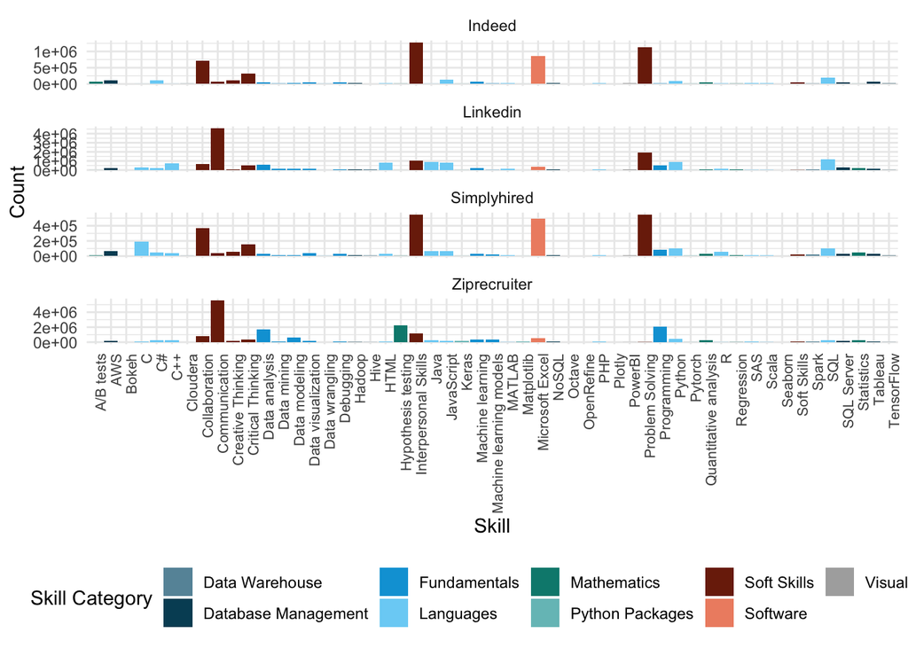

```r
mlt.tbl1 = pivot_longer(tbl1.siteskills, cols = c("indeed", "linkedin", "simplyhired", "ziprecruiter"), values_to = "count")
mlt.tbl1 = mlt.tbl1 %>% mutate(count = as.integer(gsub("\\,", "", count)))
mlt.tbl1.merged = mlt.tbl1 %>% merge(tbl2.skillcat, by = "skill_title", all.x = T)

mlt.tbl1.merged$name = str_to_sentence(mlt.tbl1.merged$name)

plt.sites = ggplot(mlt.tbl1.merged, aes(skill_title, count, fill = factor(skill_category))) + geom_bar(stat = "identity") + facet_wrap(~name, ncol = 1, scales = "free_y") + theme_minimal() + scale_fill_economist() + labs(x = "Skill", y = "Count", fill = "Skill Category") + theme(axis.text.x = element_text(size = 8, angle=90, hjust = 1, vjust = 1), legend.position = "bottom")

plot(plt.sites)
```